LABORATORIUM 6

- Hipotezy statystyczne
- Testowanie hipotez
- Błędy w testowaniu hipotez
- Statystyka testowa, zbiór krytyczny i p-wartość
- Test $\chi^2$
- Test Kołmogorowa-Smirnowa
- Testy normalności rozkładu
- Dopasowywanie parametrów rozkładów

#### **Hipotezy statystyczne**

**Hipoteza statystyczna** to przypuszczenie dotyczące nieznanego rozkładu badanej cechy, którego prawdziwość chcemy przetestowac na podstawie próby.

**Hipoteza parametryczna** to hipoteza, która dotyczy jedynie parametrów nieznanego rozkładu. Pozostałe hipotezy nazywamy **nieparametrycznymi**.

**Hipoteza prosta** to taka hipoteza, która jednoznacznie określa rozkład badanej cechy. **Hipoteza złożona** określa całą klasę rozkładów.

W praktyce rozważamy dwie hipotezy: **hipotezę zerową** $H_0$ (która zazwyczaj zakłada brak występowania zjawiska w populacji, brak odstępstw od normy) oraz **hipotezę alternatywną** $H_1$ (która zachodzi gdy hipoteza zerowa nie jest prawdziwa). **Hipoteza alternatywna** odnosi się bezpośrednio do teorii, którą chcemy zbadać.

#### **Testowanie hipotez**

Testowanie hipotez obejmuje cztery etapy:

1. Sformuowanie **hipotezy zerowej** i **alternatywnej**. Jeśli odrzucimy $H_0$ to przyjmujemy $H_1$.
2. Pobranie odpowiedniej próby do testu $X_1,X_2,X_3,\dots,X_n$.
3. Obliczenie **statystyki testowej** czyli funkcji próby $\delta(X_1,X_2,X_3,\dots,X_n)$ i/lub **p-wartości**.
4. Sprawdzenie czy wartość **statystyki testowej** leży w **zbiorze krytycznym** $W$ dla danego testu lub czy **p-wartość** jest mniejsza lub równa od przyjętego **poziomu istotności** $\alpha$. Odrzucamy $H_0$ jeśli $\delta(X_1,X_2,X_3,\dots,X_n) \in W$ lub $\text{p-wartość} \leq \alpha$. W przeciwnym wypadku mówimy, że *nie ma podstaw do odrzucenia hipotezy zerowej*.

#### **Błędy w testowaniu hipotez**

Wnioskujac o calej populacji na podstawie próby możemy popelnić jeden z dwoch błędów:

- **Błąd I rodzaju** polega na odrzuceniu hipotezy zerowej $H_0$ w sytuacji gdy jest ona prawdziwa.
- **Błąd II rodzaju** polega na przyjęciu hipotezy zerowej $H_0$ w sytuacji gdy jest ona fałszywa.

|  | Odrzuc $H_0$ | Nie odrzucaj $H_0$ |
| --- | --- | --- |
| $H_0$ prawdziwa | **Błąd I rodzaju** | Brak błędu |
| $H_0$ fałszywa | Brak błędu | **Błąd II rodzaju** |

Niestety, dla ustalonej **statystyki testowej** jeśli zmniejszamy prawdopodobieństwo **błędu I rodzaju** $P_1$ (np. przyjmując $H_0$ przy słabych dowodach jej słuszności) to rośnie prawdopodobieństwo **błędu II rodzaju** $P_2$.

W praktyce ustalamy z góry **maksymalną wartość dla prawdopodobieństwa błędu I rodzaju**. Wartość tą nazywamy **poziomem istotności testu** i oznaczamy symbolem $\alpha$ (zwykle przyjmuje się $\alpha=0.05$, $\alpha=0.005$, $\alpha=0.001$, czasami $\alpha=0.1$).

**Moc testu** $\beta$ jest to prawdopodobieństwo odrzucenia **hipotezy zerowej** gdy jest ona fałszywa, a zatem $\beta = 1 - P_2$. Im większa jest moc testu tym lepiej. Czynniki wpływające na moc:

- Wielkość próby. Moc rośnie z wielkoscią próby.
- Zmienność obserwacji. Moc wzrasta, gdy zmienność obserwacji maleje.
- Wielkość badanego efektu. Moc testu jest większa dla większych efektow.
- Poziom istotności $\alpha$. Moc testu rośnie razem z poziomem istotności (gdy $P_1$ wzrasta, to $P_2$ maleje).

#### **Statystyka testowa, zbiór krytyczny i p-wartość**

Sposób w jaki liczymy statystykę testowa i wyznaczamy zbiór krytyczny $W$ zależy od konkretnego testu statystycznego. Warto jednak zapamiętać, że **wartość statystyki testowej jest funkcją próby** i **nie** zależy od poziomu istotności $\alpha$, w przeciwieństwie do zbioru krytycznego $W$, którego granice są wyznaczane jako kwantyle rzędu $1-\alpha$ odpowiednich rozkładów prawdopodbieństw, i który **nie** zależy od danych z próby.

Plik *statystyki_testowe.pdf* (folder *Materiały dodatkowe*) zawiera wzory pozwalające obliczyć wartość statystyki testowej oraz granice zbioru krytycznego. Dokument pochodzi że strony internetowej prof. Anny Dembińskiej z Wydziału MiNI PW https://www.mini.pw.edu.pl/~dembinsk.

Najtrudniejszym do zrozumienia konceptem jest **p-wartość**. Definicja mówi, że jest to **najmniejsza wartość poziomu istotności przy której dla danej wartości statystyki testowej odrzucamy hipotezę zerowa** $H_0$. Wynika z tego, że **p-wartość** zależy od wartości statystyki testowej (czyli zależy od próby).

**P-wartość jest prawdopodobieństwem otrzymania wyników z próby lub wyników bardziej skrajnych, jeżeli hipoteza zerowa jest prawdziwa.** Innymi słowy, **p-wartość** jest prawdopodobieństwem tego, że zaobserwowane w danych zjawisko mogło wystapic przypadkowo i że w calej populacji takie zjawisko wcale nie występuje.

#### **Test $\chi^2$**

Jeden z najczęściej wykorzystywanych testów do sprawdzania zgodności danych eksperymentalnych z teoretycznymi. W przypadku R realizuje go funkcja `chisq.test(x, p)`, w której jako pierwszy argument podajemy liczbę zliczeń (histogram), a jako `p` teoretyczne wartości prawdopodobieństw. Hipoteza zerowa $H_0$ w tym przypadku jest taka, że liczba zliczeń podzielona przez całkowitą liczbę zliczeń jest równa teoretycznym wartościom prawdopodobieństwa

```r
x <- c(100,50,20,10,5)
p1 <- c(0.5, 0.2, 0.2, 0.05, 0.05)
chisq.test (x, p = p1)
```

```
##
##  Chi-squared test for given probabilities
##
## data:  x
## X-squared = 15, df = 4, p-value = 0.004701
```

```r
p2 <- c(0.5, 0.3, 0.1, 0.05, 0.05)
chisq.test( x, p = p2)
```

```
##
##  Chi-squared test for given probabilities
##
## data:  x
## X-squared = 3.2883, df = 4, p-value = 0.5108
```

```r
p <- x/sum(x)
chisq.test (x, p = p)
```

```
##
##  Chi-squared test for given probabilities
##
## data:  x
## X-squared = 0, df = 4, p-value = 1
```

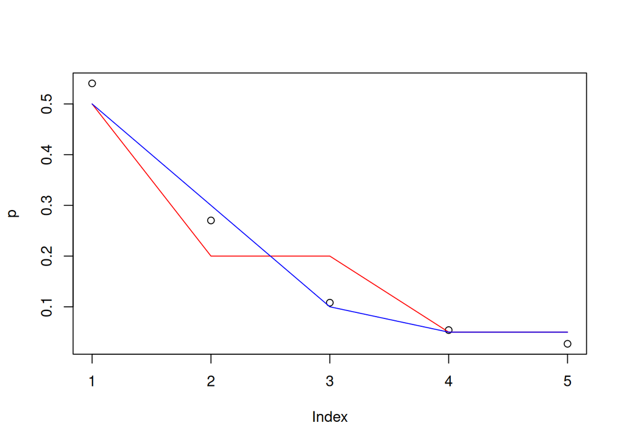

```r
plot (p)
lines (p1, col="red")
lines (p2, col="blue")
```

**UWAGA 1:** Jest to test do rozkładów **dyskretnych**.

**UWAGA 2:** Prawdopodobieństwa muszą się sumować do 1, w przeciwnym wypadku otrzymamy błąd, możliwe jest przeskalowanie poprzez parametr **rescale.p=TRUE**)

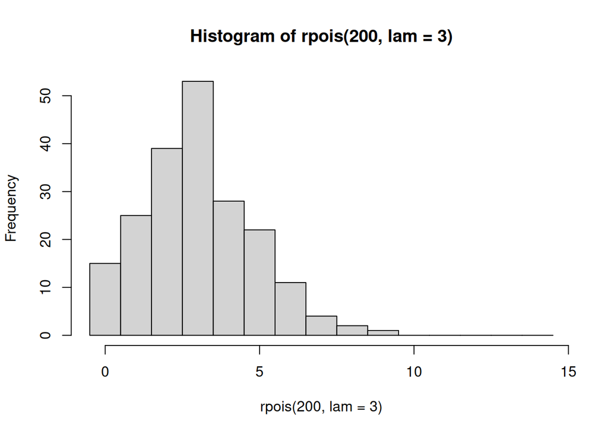

```r
h <- hist (rpois(200, lam = 3), breaks = (0:15)-0.5)
```

```r
chisq.test (h$counts, p = dpois(h$mids, lam = 3))
```

```
## Error in chisq.test(h$counts, p = dpois(h$mids, lam = 3)): probabilities must sum to 1.
```

```r
chisq.test (h$counts, p = dpois(h$mids, lam = 3), rescale.p = TRUE)
```

```
##
##  Chi-squared test for given probabilities
##
## data:  h$counts
## X-squared = 7.5096, df = 14, p-value = 0.9133
```

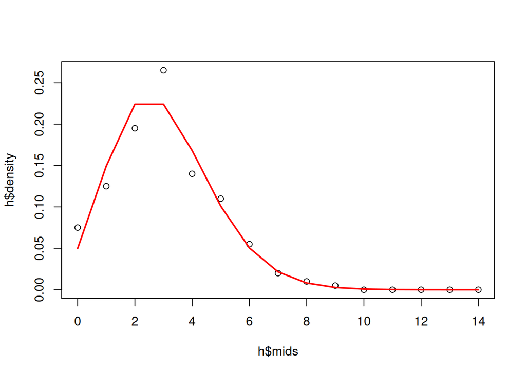

```r
plot (h$mids, h$density)
lines (h$mids, dpois(h$mids, lam = 3), col="red", lwd=2)
```

#### **Test Kołmogorowa-Smirnowa**

Jest realizowany poprzez funkcję `ks.test()`. Może być stosowany zarówno do rozkładów dyskretnych jak i ciągłych. Przy jego pomocy można porównywać dwa rozkłady eksperymentalne albo rozkład eksperymentalny z rozkładem teoretycznym (ale tylko ciągłym). Test operuje na tzw. **statystyce odstępu**, badając, czy największa odległość pomiędzy dwiema dystybuantami mieści się w zakresie ww. statystyki. Hipoteza zerowa zakłada, że obie próbki (lub próba i rozkład) pochodzą z tego samego rozkładu.

```r
x <- rnorm (100)
y <- rnorm (100)
ks.test (x, y)
```

```
##
##  Asymptotic two-sample Kolmogorov-Smirnov test
##
## data:  x and y
## D = 0.12, p-value = 0.4676
## alternative hypothesis: two-sided
```

```r
y <- rnorm (100, 1, 2)
ks.test (x, y)
```

```
##
##  Asymptotic two-sample Kolmogorov-Smirnov test
##
## data:  x and y
## D = 0.32, p-value = 7.143e-05
## alternative hypothesis: two-sided
```

```r
ks.test (x, "pnorm", 0, 1)
```

```
##
##  Asymptotic one-sample Kolmogorov-Smirnov test
##
## data:  x
## D = 0.080439, p-value = 0.537
## alternative hypothesis: two-sided
```

```r
x <- rpois (100, lam = 5)
y <- rpois (100, lam = 5)
ks.test (x, y)
```

```
##
##  Asymptotic two-sample Kolmogorov-Smirnov test
##
## data:  x and y
## D = 0.11, p-value = 0.5806
## alternative hypothesis: two-sided
```

```r
y <- rpois (100, lam = 2)
ks.test (x, y)
```

```
##
##  Asymptotic two-sample Kolmogorov-Smirnov test
##
## data:  x and y
## D = 0.64, p-value < 2.2e-16
## alternative hypothesis: two-sided
```

```r
# Wynik poniższego testu będzie niepoprawny, ponieważ rozkład Poissona jest rozkładem dyskretnym
ks.test (x, "ppois", lam = 5)
```

```
##
##  Asymptotic one-sample Kolmogorov-Smirnov test
##
## data:  x
## D = 0.22049, p-value = 0.0001197
## alternative hypothesis: two-sided
```

#### **Testy normalności rozkładu**

```r
shapiro.test (rnorm(100))
```

```
##
##  Shapiro-Wilk normality test
##
## data:  rnorm(100)
## W = 0.99337, p-value = 0.9094
```

```r
shapiro.test (rnorm(100, 0, 5))
```

```
##
##  Shapiro-Wilk normality test
##
## data:  rnorm(100, 0, 5)
## W = 0.98715, p-value = 0.4476
```

```r
shapiro.test (runif(100, 0, 1))
```

```
##
##  Shapiro-Wilk normality test
##
## data:  runif(100, 0, 1)
## W = 0.93821, p-value = 0.0001502
```

```r
wilcox.test (rnorm(100))
```

```
##
##  Wilcoxon signed rank test with continuity correction
##
## data:  rnorm(100)
## V = 2426, p-value = 0.7349
## alternative hypothesis: true location is not equal to 0
```

```r
wilcox.test (rnorm(100, 1, 2), mu = 1)
```

```
##
##  Wilcoxon signed rank test with continuity correction
##
## data:  rnorm(100, 1, 2)
## V = 2254, p-value = 0.3523
## alternative hypothesis: true location is not equal to 1
```

```r
wilcox.test (rnorm(100, 1, 2), mu = 2)
```

```
##
##  Wilcoxon signed rank test with continuity correction
##
## data:  rnorm(100, 1, 2)
## V = 1178, p-value = 3.662e-06
## alternative hypothesis: true location is not equal to 2
```

#### **Dopasowywanie parametrów rozkładów**

Za pomocą funkcji `fitdistr()` (biblioteka `MASS`) możliwa jest estymacja nieznanych parametrów rozkładów, przy czym postać rozkładu musi być uprzednio znana - może to być albo jeden z wbudowanych rozkładów albo też nasza własna funkcja gęstości prawdopodobieństwa. W przypadku niektórych rozkładów, np. normalnego albo wykładniczego, nie jest potrzebne podawanie wartości początkowych dla szukanych parametrów.

```r
library(MASS)

x <- rnorm (200, mean = 5, sd = 1.5)
fit1 <- fitdistr (x, "normal")
fit1
```

```
##       mean          sd
##   4.96263206   1.73066128
##  (0.12237623) (0.08653306)
```

```r
y <- rexp (200, rate = 0.5)
fit2 <- fitdistr (y, "exponential")
fit2
```

```
##       rate
##   0.55959212
##  (0.03956914)
```

```r
z <- rweibull (200, scale = 1.5, shape = 3)
fit3 <- fitdistr (z, "weibull", list (scale = 1, shape = 1))
fit3
```

```
##      scale        shape
##   1.49906769   2.84198088
##  (0.03905457) (0.16166448)
```

Obiekt, który powstaje po dopasowaniu ma następujące istotne pola: `estimate`, `sd` oraz `loglik`. Pierwsze dwa podają odpowiednio oszacowanie parametrów rozkładu oraz ich odchylenia standardowe, ostatnie to logarytm z funkcji wiarygodności. Funkcja ta jest maksymalizowana w iteracyjnym procesie dopasowywania parametrów rozkładu.

```r
fit1$estimate
```

```
##     mean       sd
## 4.962632 1.730661
```

```r
fit1$sd
```

```
##       mean         sd
## 0.12237623 0.08653306
```

```r
fit1$loglik
```

```
## [1] -393.4884
```

Nic nie stoi na przeszkodzie aby sprawdzić hipotezę, czy dane faktycznie mogą pochodzić z rozkładów o wyestymowanych parametrach.

```r
# Testowanie rozkładu normalnego
wilcox.test (x, mu = fit1$estimate["mean"])
```

```
##
##  Wilcoxon signed rank test with continuity correction
##
## data:  x
## V = 10170, p-value = 0.8841
## alternative hypothesis: true location is not equal to 4.962632
```

```r
# Testowanie rozkładu wykładniczego
ks.test (y, "pexp", rate = fit2$estimate["rate"])
```

```
##
##  Asymptotic one-sample Kolmogorov-Smirnov test
##
## data:  y
## D = 0.04616, p-value = 0.7877
## alternative hypothesis: two-sided
```

```r
# Testowanie rozkładu Weibulla
ks.test (z, "pweibull", scale = fit3$estimate["scale"], shape = fit3$estimate["shape"])
```

```
##
##  Asymptotic one-sample Kolmogorov-Smirnov test
##
## data:  z
## D = 0.043084, p-value = 0.8517
## alternative hypothesis: two-sided
```

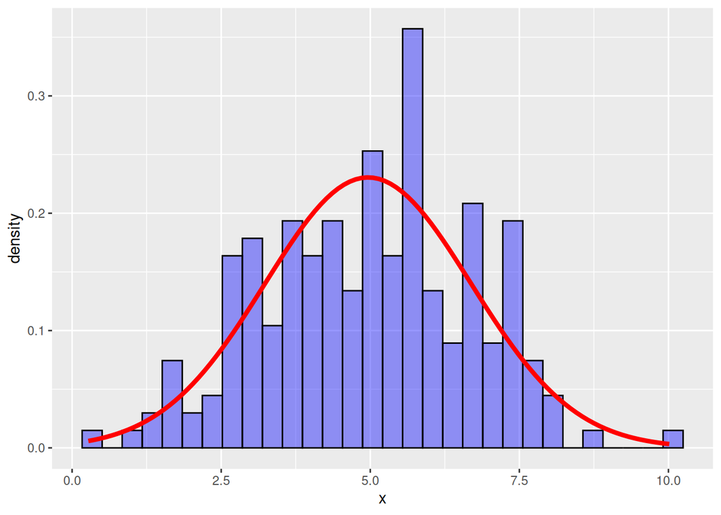

```r
# Rysowanie
library(ggplot2)
g <- ggplot (data.frame(x,y,z))

g + geom_histogram(aes(x = x,..density..), fill="blue", colour="black", alpha=0.4) +
  stat_function(fun = dnorm,
                args = list(mean = fit1$estimate["mean"],
                            sd = fit1$estimate["sd"]),
                colour="red",
                size=1.5)
```

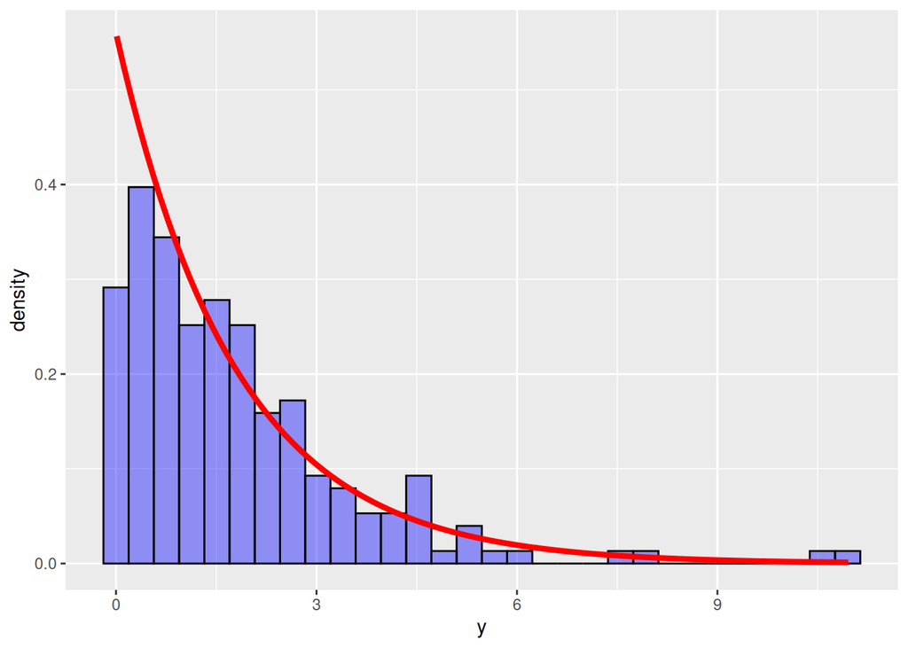

```r
g + geom_histogram(aes(x = y,..density..), fill="blue", colour="black", alpha=0.4) +
  stat_function(fun = dexp,
                args = list(rate = fit2$estimate["rate"]),
                colour="red",
                size=1.5)
```

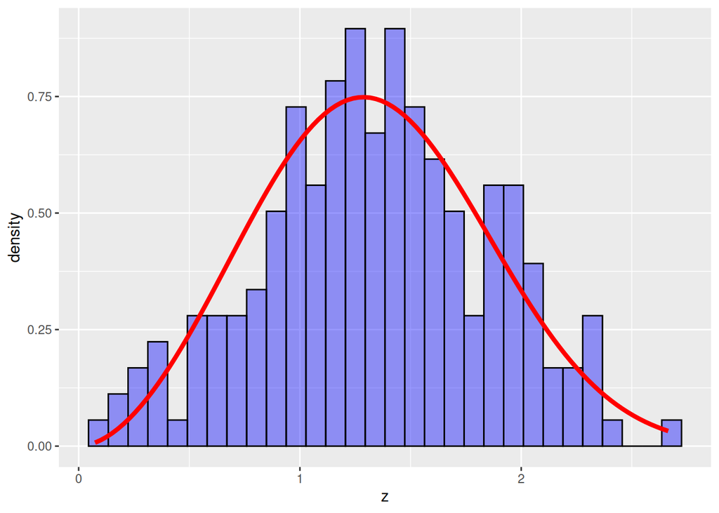

```r
g + geom_histogram(aes(x = z,..density..), fill="blue", colour="black", alpha=0.4) +
  stat_function(fun = dweibull,
                args = list(scale = fit3$estimate["scale"], shape = fit3$estimate["shape"]),
                colour="red",
                size=1.5)
```